# Exploring Possible Predictors of Systolic Blood Pressure in Adults

# 1 Setup and Data Ingest

## 1.1 Initial Setup and Package Loads in R

```r
source("Love-boost.R")
library(nhanesA)
library(knitr)
library(rmdformats)
library(rmarkdown)
library(Hmisc)
library(GGally)
library(patchwork)
library(car)
library(gt)
library(gtExtras)
library(kableExtra)
library(ggrepel)
library(ggdist)
library(glue)
library(equatiomatic)
library(janitor)
library(mosaic)
library(naniar)
library(broom)
library(tidyverse)
library(patchwork)

## Global options

opts_chunk$set(comment=NA)
opts_knit$set(width=75)

theme_set(theme_bw())
options(dplyr.summarise.inform = FALSE)
```

## 1.2 Loading the Raw Data into R

```r
demo_raw <- nhanes('P_DEMO') %>% tibble()%>% clean_names()
bp_raw <- nhanes("P_BPXO")%>% tibble()%>% clean_names()
fat_raw <- nhanes("P_DR1TOT")%>% tibble()%>% clean_names()
ghb_raw <- nhanes("P_GHB")%>% tibble()%>% clean_names()
smoke_raw <- nhanes("P_SMQ")%>% tibble()%>% clean_names()
weight_raw <- nhanes("P_WHQ")%>% tibble()%>% clean_names()
```

```r
demo <- demo_raw %>% select(seqn, ridstatr, ridageyr, ridreth3) %>%
  filter(ridstatr==2) %>%
  filter(ridageyr %in% (18:70))

bp <- bp_raw |> select(seqn, bpxosy1)

fats <- fat_raw |> select(seqn, dr1tsfat)

ghb <- ghb_raw |> select(seqn, lbxgh)

smoke <- smoke_raw |> select(seqn, smq040)

weight <- weight_raw |> select(seqn, whq030)
```

```r
temp_1 <- left_join(demo, bp, by="seqn")
temp_2 <- left_join(temp_1, fats, by="seqn")
temp_3 <- left_join(temp_2, ghb, by="seqn")
temp_4 <- left_join(temp_3, weight, by="seqn")
temp_5 <- left_join(temp_4, smoke, by="seqn")

dim(temp_5)
```

```
[1] 7611    9
```

```r
clean_names(temp_5)
```

```
# A tibble: 7,611 × 9
     seqn ridstatr ridageyr ridreth3 bpxosy1 dr1tsfat lbxgh whq030 smq040
    <dbl>    <dbl>    <dbl>    <dbl>   <dbl>    <dbl> <dbl>  <dbl>  <dbl>
 1 109266        2       29        6      99    22.2    5.2      1     NA
 2 109271        2       49        3     102    39.2    5.6      3      1
 3 109273        2       36        3     116     2.70   5.1      2      1
 4 109274        2       68        7     138    21.8    5.7      1     NA
 5 109284        2       44        1      NA    30.7    5.6      1     NA
 6 109286        2       33        6      NA    49.9    5.7      1     NA
 7 109290        2       68        4     126     4.80   8.4      3     NA
 8 109291        2       42        6     107    13.8    4.9      3     NA
 9 109292        2       58        2     143    NA      6.4      1     NA
10 109293        2       44        3     126    28.0    5.3      1     NA
# … with 7,601 more rows
```

```r
glimpse(temp_5)
```

```
Rows: 7,611
Columns: 9
$ seqn     <dbl> 109266, 109271, 109273, 109274, 109284, 109286, 109290, 10929…
$ ridstatr <dbl> 2, 2, 2, 2, 2, 2, 2, 2, 2, 2, 2, 2, 2, 2, 2, 2, 2, 2, 2, 2, 2…
$ ridageyr <dbl> 29, 49, 36, 68, 44, 33, 68, 42, 58, 44, 54, 30, 68, 54, 18, 5…
$ ridreth3 <dbl> 6, 3, 3, 7, 1, 6, 4, 6, 2, 3, 1, 6, 3, 6, 6, 6, 6, 3, 3, 4, 4…
$ bpxosy1  <dbl> 99, 102, 116, 138, NA, NA, 126, 107, 143, 126, 158, 105, 94, …
$ dr1tsfat <dbl> 22.175, 39.178, 2.698, 21.800, 30.681, 49.936, 4.802, 13.769,…
$ lbxgh    <dbl> 5.2, 5.6, 5.1, 5.7, 5.6, 5.7, 8.4, 4.9, 6.4, 5.3, 5.3, 5.1, 8…
$ whq030   <dbl> 1, 3, 2, 1, 1, 1, 3, 3, 1, 1, 3, 3, 1, 3, 2, 2, 3, 3, 3, 1, 3…
$ smq040   <dbl> NA, 1, 1, NA, NA, NA, NA, NA, NA, NA, NA, NA, NA, NA, NA, NA,…
```

```r
dim(temp_5)
```

```
[1] 7611    9
```

```r
clean_names(temp_5)
```

```
# A tibble: 7,611 × 9
     seqn ridstatr ridageyr ridreth3 bpxosy1 dr1tsfat lbxgh whq030 smq040
    <dbl>    <dbl>    <dbl>    <dbl>   <dbl>    <dbl> <dbl>  <dbl>  <dbl>
 1 109266        2       29        6      99    22.2    5.2      1     NA
 2 109271        2       49        3     102    39.2    5.6      3      1
 3 109273        2       36        3     116     2.70   5.1      2      1
 4 109274        2       68        7     138    21.8    5.7      1     NA
 5 109284        2       44        1      NA    30.7    5.6      1     NA
 6 109286        2       33        6      NA    49.9    5.7      1     NA
 7 109290        2       68        4     126     4.80   8.4      3     NA
 8 109291        2       42        6     107    13.8    4.9      3     NA
 9 109292        2       58        2     143    NA      6.4      1     NA
10 109293        2       44        3     126    28.0    5.3      1     NA
# … with 7,601 more rows
```

## 1.3 List of missing values

```r
miss_var_summary(temp_5)
```

```
# A tibble: 9 × 3
  variable n_miss pct_miss
  <chr>     <int>    <dbl>
1 smq040     4678    61.5
2 bpxosy1     740     9.72
3 dr1tsfat    673     8.84
4 lbxgh       426     5.60
5 seqn          0     0
6 ridstatr      0     0
7 ridageyr      0     0
8 ridreth3      0     0
9 whq030        0     0
```

I have assumed that my data is missing completely at random (MCAR). For further analysis, I’ll be using only complete cases.

```r
temp_6 <- temp_5[!(temp_5$whq030==7 | temp_5$whq030==9),]
```

```r
temp_7 <- temp_6 |> select(seqn, ridstatr, ridageyr, ridreth3, bpxosy1, dr1tsfat, smq040, whq030, lbxgh) |> drop_na()
```

### 1.3.1 Recoding, relevling and renaming the variables.

```r
temp_7 <- temp_7 %>% mutate(smoking = fct_recode(factor(smq040),
"Every day" = "1",
"Some days" = "2",
"Not at all" = "3"))

temp_7 %>% tabyl(smoking) |> filter(complete.cases(smoking))
```

```
    smoking    n   percent
  Every day  931 0.3804659
  Some days  283 0.1156518
 Not at all 1233 0.5038823
```

```r
temp_7 <- temp_7 |> mutate(weight_history = fct_recode(factor(whq030),
"Overweight" = "3", "Underweight" = "2", "Ideal weight" = "1"))

temp_7 |> tabyl(weight_history)
```

```
 weight_history    n    percent
   Ideal weight 1324 0.54107070
    Underweight  163 0.06661218
     Overweight  960 0.39231712
```

```r
temp_7 <- temp_7 %>% mutate(ethnicity = fct_recode(factor(ridreth3),
"Mexican American" = "1",
"Hispanic" = "2",
"White" = "3",
"Black" = "4",
"Asian" = "6",
"Other Race" = "7"),
ethnicity = fct_relevel(ethnicity, "White"))

temp_7 %>% tabyl(ethnicity)
```

```
        ethnicity   n    percent
            White 979 0.40008173
 Mexican American 260 0.10625255
         Hispanic 217 0.08868002
            Black 676 0.27625664
            Asian 144 0.05884757
       Other Race 171 0.06988149
```

```r
temp_7 <- temp_7 |> rename("systolic_BP"= "bpxosy1", "sat_FA"="dr1tsfat", "glycohemoglobin" = "lbxgh")
```

```r
glimpse(temp_7)
```

```
Rows: 2,447
Columns: 12
$ seqn            <dbl> 109271, 109273, 109307, 109317, 109331, 109334, 109335…
$ ridstatr        <dbl> 2, 2, 2, 2, 2, 2, 2, 2, 2, 2, 2, 2, 2, 2, 2, 2, 2, 2, …
$ ridageyr        <dbl> 49, 36, 47, 28, 19, 54, 55, 48, 43, 49, 41, 47, 51, 60…
$ ridreth3        <dbl> 3, 3, 6, 4, 1, 3, 4, 4, 3, 2, 3, 3, 4, 3, 3, 3, 7, 4, …
$ systolic_BP     <dbl> 102, 116, 115, 110, 106, 114, 102, 104, 100, 120, 126,…
$ sat_FA          <dbl> 39.178, 2.698, 25.130, 38.819, 40.122, 14.297, 32.285,…
$ smq040          <dbl> 1, 1, 3, 3, 1, 1, 1, 3, 1, 1, 1, 3, 3, 3, 1, 1, 1, 1, …
$ whq030          <dbl> 3, 2, 3, 1, 3, 3, 1, 1, 1, 1, 1, 1, 2, 3, 2, 1, 2, 1, …
$ glycohemoglobin <dbl> 5.6, 5.1, 5.3, 5.0, 5.3, 5.6, 6.3, 5.5, 5.2, 5.3, 5.4,…
$ smoking         <fct> Every day, Every day, Not at all, Not at all, Every da…
$ weight_history  <fct> Overweight, Underweight, Overweight, Ideal weight, Ove…
$ ethnicity       <fct> White, White, Asian, Black, Mexican American, White, B…
```

I have combined all the required variables and created a new tibble called study2.

```r
study2 <- temp_7 |> select(seqn, ridstatr, ridageyr, systolic_BP, ethnicity, sat_FA, glycohemoglobin, smoking, weight_history) |> glimpse()
```

```
Rows: 2,447
Columns: 9
$ seqn            <dbl> 109271, 109273, 109307, 109317, 109331, 109334, 109335…
$ ridstatr        <dbl> 2, 2, 2, 2, 2, 2, 2, 2, 2, 2, 2, 2, 2, 2, 2, 2, 2, 2, …
$ ridageyr        <dbl> 49, 36, 47, 28, 19, 54, 55, 48, 43, 49, 41, 47, 51, 60…
$ systolic_BP     <dbl> 102, 116, 115, 110, 106, 114, 102, 104, 100, 120, 126,…
$ ethnicity       <fct> White, White, Asian, Black, Mexican American, White, B…
$ sat_FA          <dbl> 39.178, 2.698, 25.130, 38.819, 40.122, 14.297, 32.285,…
$ glycohemoglobin <dbl> 5.6, 5.1, 5.3, 5.0, 5.3, 5.6, 6.3, 5.5, 5.2, 5.3, 5.4,…
$ smoking         <fct> Every day, Every day, Not at all, Not at all, Every da…
$ weight_history  <fct> Overweight, Underweight, Overweight, Ideal weight, Ove…
```

## 1.4 Data Summary

Here’s a summary of the `study2` tibble.

```r
Hmisc::describe(study2)
```

```
study2

 9  Variables      2447  Observations
--------------------------------------------------------------------------------
seqn
       n  missing distinct     Info     Mean      Gmd      .05      .10
    2447        0     2447        1   117230     5172   110227   110914
     .25      .50      .75      .90      .95
  113313   117313   121172   123322   124005

lowest : 109271 109273 109307 109317 109331, highest: 124798 124807 124812 124814 124815
--------------------------------------------------------------------------------
ridstatr
       n  missing distinct     Info     Mean      Gmd
    2447        0        1        0        2        0

Value         2
Frequency  2447
Proportion    1
--------------------------------------------------------------------------------
ridageyr
       n  missing distinct     Info     Mean      Gmd      .05      .10
    2447        0       53        1    48.26    16.52       24       28
     .25      .50      .75      .90      .95
      36       50       61       66       68

lowest : 18 19 20 21 22, highest: 66 67 68 69 70
--------------------------------------------------------------------------------
systolic_BP
       n  missing distinct     Info     Mean      Gmd      .05      .10
    2447        0      111        1    124.2    20.71       98      103
     .25      .50      .75      .90      .95
     111      121      135      149      160

lowest :  66  76  78  82  83, highest: 194 200 201 205 208
--------------------------------------------------------------------------------
ethnicity
       n  missing distinct
    2447        0        6

```

[output cut: 29 more lines]

```
       n  missing distinct
    2447        0        3

Value       Every day  Some days Not at all
Frequency         931        283       1233
Proportion      0.380      0.116      0.504
--------------------------------------------------------------------------------
weight_history
       n  missing distinct
    2447        0        3

Value      Ideal weight  Underweight   Overweight
Frequency          1324          163          960
Proportion        0.541        0.067        0.392
--------------------------------------------------------------------------------
```

# 2 Codebook and Data Description

## 2.1 Codebook

The variables in our data set `study2` for this demonstration are as follows. The Type column indicates the number of levels in each categorical (factor) variable. I’m using Quant to indicate quantitative variables, and Cat-x indicates a categorical variable (factor) with x levels.

[output not shown]

# 3 Analysis

## 3.2 Partitioning the data

I have partitioned study2 data into train (70%) and test sample (30%).

```r
set.seed(4312022)

study_b_train <- study2 %>%
    slice_sample(., prop = 0.70)

study_b_test <-
    anti_join(study2, study_b_train, by = "seqn")

c(nrow(study2), nrow(study_b_train), nrow(study_b_test))
```

```
[1] 2447 1712  735
```

# 4 Transforming the outcome

## 4.1 Visualizing the Outcome Distribution

Checking whether a normal model fits my outcome.

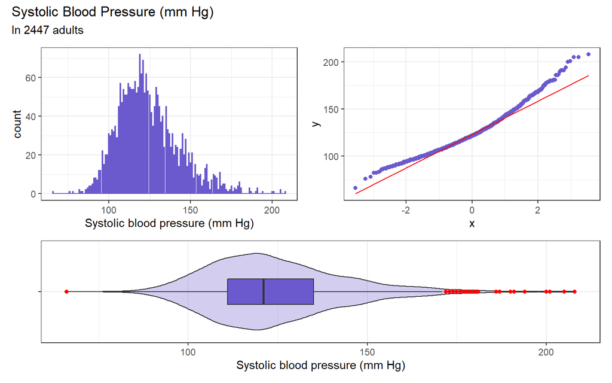

```r
p1 <- ggplot(study2, aes(x = systolic_BP)) +
  geom_histogram(binwidth = 0.5,
                 fill = "slateblue", col = "slateblue") +
labs(x= "Systolic blood pressure (mm Hg)")

p2 <- ggplot(study2, aes(sample = systolic_BP)) +
  geom_qq(col = "slateblue") + geom_qq_line(col = "red")

p3 <- ggplot(study2, aes(x = "", y = systolic_BP)) +
  geom_violin(fill = "slateblue", alpha = 0.3) +
  geom_boxplot(fill = "slateblue", width = 0.3,
               outlier.color = "red") +
  labs(x = "", y = "Systolic blood pressure (mm Hg)") + coord_flip()

p1 + p2 - p3 +
  plot_layout(ncol = 1, height = c(3, 2)) +
  plot_annotation(title = "Systolic Blood Pressure (mm Hg)",
         subtitle = glue("In 2447 adults"))
```

Our data in the histogram doesn’t look normally distributed (looks right skewed). The qq plot and the violin box plot also suggest right skew with few outliers.

## 4.2 Numerical Summary

```r
favstats(~ systolic_BP, data = study_b_train)
```

```
 min  Q1 median  Q3 max    mean       sd    n missing
  66 111    121 135 208 124.118 19.10885 1712       0
```

## 4.3 Numerical Summaries of the Predictors

```r
study_b_train |> select(-seqn, -ethnicity) |>
  mosaic::inspect()
```

```
categorical variables:
            name  class levels    n missing
1        smoking factor      3 1712       0
2 weight_history factor      3 1712       0
                                   distribution
1 Not at all (49.7%), Every day (38.4%) ...
2 Ideal weight (54%) ...

quantitative variables:
             name   class min        Q1  median       Q3     max       mean
1        ridstatr numeric   2   2.00000   2.000   2.0000   2.000   2.000000
2        ridageyr numeric  18  36.00000  49.000  61.0000  70.000  48.040888
3     systolic_BP numeric  66 111.00000 121.000 135.0000 208.000 124.117991
4          sat_FA numeric   0  16.15375  25.894  39.1615 141.868  29.717303
5 glycohemoglobin numeric   4   5.30000   5.600   6.0000  15.400   5.870035
         sd    n missing
1  0.000000 1712       0
2 14.365138 1712       0
3 19.108845 1712       0
4 18.811841 1712       0
5  1.238665 1712       0
```

## 4.4 Scatterplot matrix

Using scatterplot matrix to look for potential ccollinearity issues among my variables and predictors.

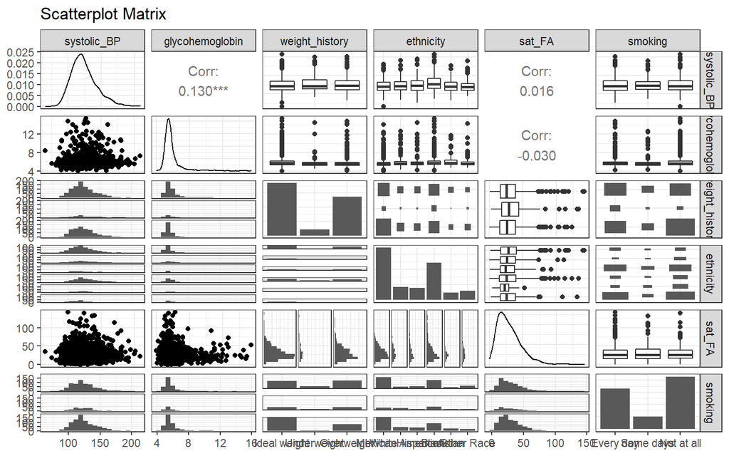

```
                    GVIF Df GVIF^(1/(2*Df))
glycohemoglobin 1.041096  1        1.020341
weight_history  1.099517  2        1.024001
ethnicity       1.098492  5        1.009438
sat_FA          1.015762  1        1.007850
smoking         1.093941  2        1.022701
```

## 4.5 `boxCox` function to assess need for transformation of our outcome

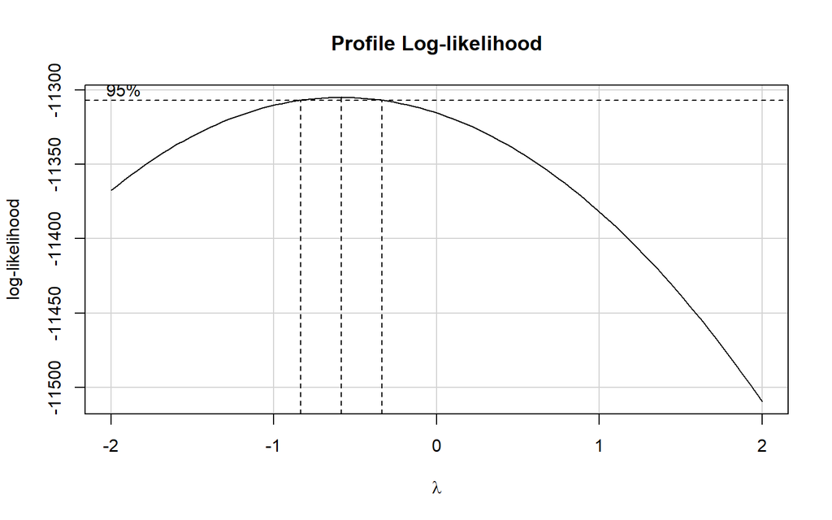

```r
model_temp <- lm(systolic_BP ~ glycohemoglobin + weight_history + ethnicity + sat_FA + smoking, data = study_b_train)

boxCox(model_temp)
```

```r
powerTransform(model_temp)
```

```
Estimated transformation parameter
        Y1
-0.5865974
```

Now, I have plotted my transformed outcome (1/systolic_BP), to assess whether my data looks normal after transformation or not.

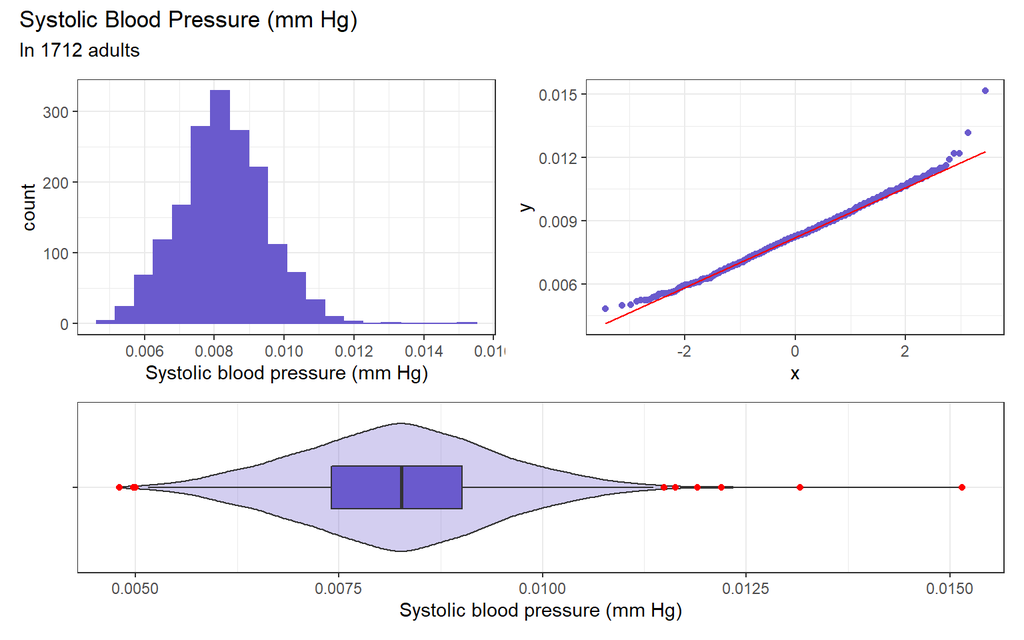

```r
p1 <- ggplot(study_b_train, aes(x = 1/systolic_BP)) +
  geom_histogram(bins = 20, fill = "slateblue", col = "slateblue") +
labs(x= "Systolic blood pressure (mm Hg)")

p2 <- ggplot(study_b_train, aes(sample = 1/systolic_BP)) +
  geom_qq(col = "slateblue") + geom_qq_line(col = "red")

p3 <- ggplot(study_b_train, aes(x = "", y = 1/systolic_BP)) +
  geom_violin(fill = "slateblue", alpha = 0.3) +
  geom_boxplot(fill = "slateblue", width = 0.3,
               outlier.color = "red") +
  labs(x = "", y = "Systolic blood pressure (mm Hg)") + coord_flip()

p1 + p2 - p3 +
  plot_layout(ncol = 1, height = c(3, 2)) +
  plot_annotation(title = "Systolic Blood Pressure (mm Hg)",
         subtitle = glue("In 1712 adults"))
```

Using inverse transformation for my outcome, systolic blood pressure, changes it distribution to normal, more symmetric, with less outliers.

Using a linear model to assess how my outcomes transformation changes its relationship with my key predictor glycohemoglobin (Hb1Ac).

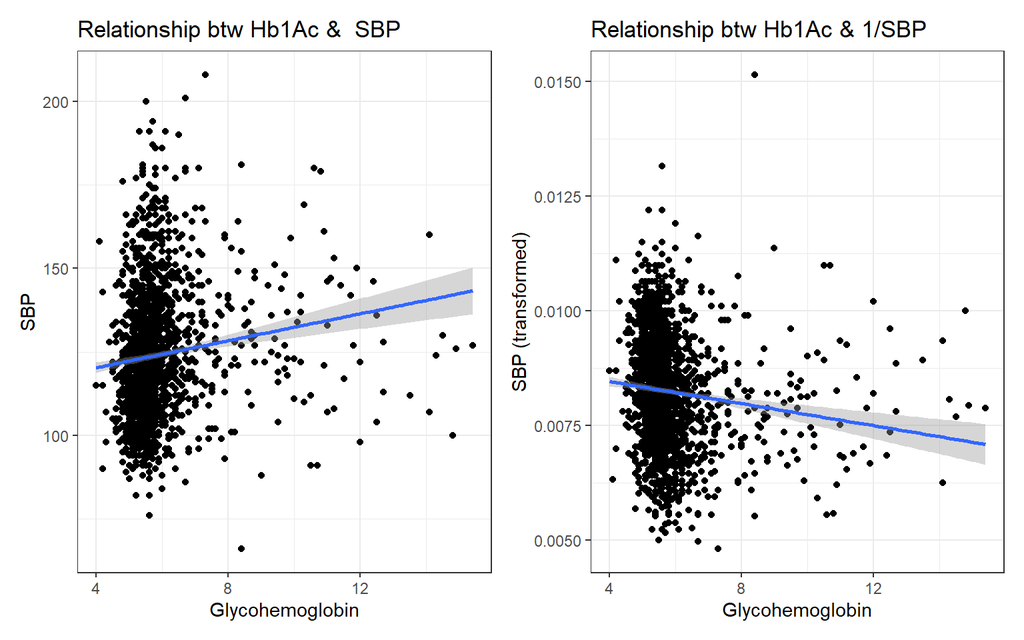

```r
p7 <- ggplot(data = study_b_train, aes(x = glycohemoglobin, y = systolic_BP)) +
geom_point() +
geom_smooth(method = "lm", formula = y ~ x) +
labs(x = "Glycohemoglobin",
y = "SBP",
title = "Relationship btw Hb1Ac &  SBP")

p8 <- ggplot(data = study_b_train, aes(x = glycohemoglobin, y = 1/systolic_BP)) +
geom_point() +
geom_smooth(method = "lm", formula = y ~ x) +
labs(x = "Glycohemoglobin",
y = "SBP (transformed)",
title = "Relationship btw Hb1Ac & 1/SBP")

p7 +  p8
```

The first plot shows a positive relationship between my outcome and my key predictor. However, after the outcome’s transformation, the relationship changes to negative.

# 5 The Small Model

The small model uses only my predictor and outcome.

```r
model1 <- lm(1/systolic_BP ~ glycohemoglobin, data = study_b_train)

extract_eq(model1, use_coefs = TRUE, coef_digits = 4,
           ital_vars = TRUE)
```

$$\widehat{1/systolic\_BP} = 0.0089 - 1e-04(glycohemoglobin)$$

```r
tidy_m1 <- tidy(model1, conf.int = TRUE, conf.level = 0.90)
tidy_m1 |>
  select(term, estimate, std.error, p.value, conf.low, conf.high) |>
  kbl(digits = 4) |>
  kable_styling(font_size = 18, full_width = F)
```

| term | estimate | std.error | p.value | conf.low | conf.high |
| --- | --- | --- | --- | --- | --- |
| (Intercept) | 0.0089 | 1e-04 | 0 | 0.0087 | 0.0092 |
| glycohemoglobin | -0.0001 | 0e+00 | 0 | -0.0002 | -0.0001 |

```r
summary(model1)
```

```
Call:
lm(formula = 1/systolic_BP ~ glycohemoglobin, data = study_b_train)

Residuals:
       Min         1Q     Median         3Q        Max
-0.0032837 -0.0007933 -0.0000072  0.0007726  0.0072168

Coefficients:
                  Estimate Std. Error t value Pr(>|t|)
(Intercept)      8.946e-03  1.410e-04  63.425  < 2e-16 ***
glycohemoglobin -1.203e-04  2.351e-05  -5.119 3.42e-07 ***
---
Signif. codes:  0 '***' 0.001 '**' 0.01 '*' 0.05 '.' 0.1 ' ' 1

Residual standard error: 0.001205 on 1710 degrees of freedom
Multiple R-squared:  0.01509,   Adjusted R-squared:  0.01452
F-statistic:  26.2 on 1 and 1710 DF,  p-value: 3.418e-07
```

```r
glance(model1) |>
select(r.squared, adj.r.squared, sigma, statistic, p.value, nobs,
logLik:deviance) |> kable(digits = 3) |> kable_styling(font_size = 18)
```

| r.squared | adj.r.squared | sigma | statistic | p.value | nobs | logLik | AIC | BIC | deviance |
| --- | --- | --- | --- | --- | --- | --- | --- | --- | --- |
| 0.015 | 0.015 | 0.001 | 26.204 | 0 | 1712 | 9079.214 | -18152.43 | -18136.09 | 0.002 |

Model 1 explains only 1.5% variation in the data.

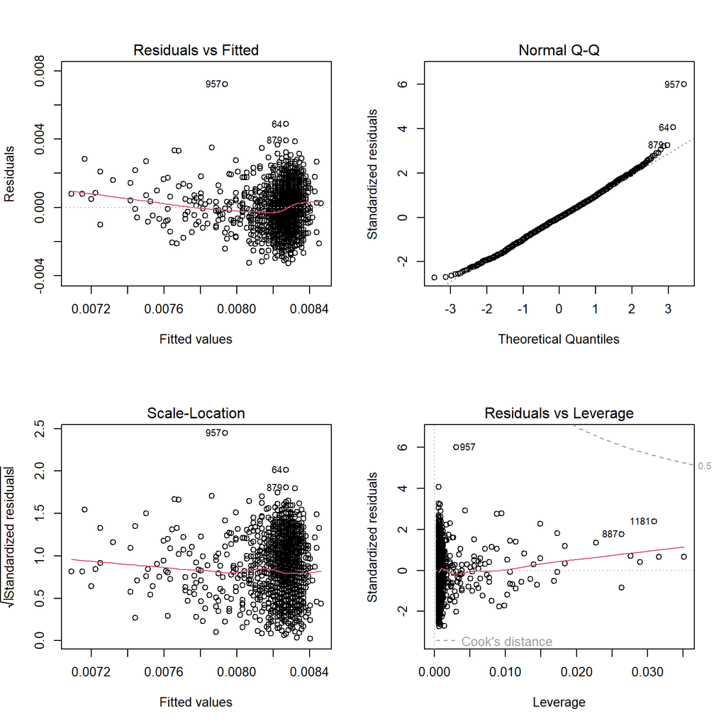

```r
par(mfrow = c(2,2)); plot(model1); par(mfrow = c(1,1))
```

**Normal Q-Q Plot** - The residuals on the QQ plot looks pretty normal. Also, there are a few outliers.

# 6 The Big Model

I have created a big model using all my predictors.

```r
model2 <- lm(1/systolic_BP ~ glycohemoglobin + weight_history + ethnicity + sat_FA + smoking, data= study_b_train)
extract_eq(model2, use_coefs = TRUE, coef_digits = 4,
           ital_vars = TRUE, wrap = TRUE)
```

$$\begin{aligned}
\widehat{1/systolic\_BP} &= 0.0092 - 1e-04(glycohemoglobin) -
1e-04(weight\_history_{Underweight}) -
1e-04(weight\_history_{Overweight})\ - \\
&\quad 1e-04(ethnicity_{Mexican\ American}) +
0(ethnicity_{Hispanic}) - 4e-04(ethnicity_{Black}) +
0(ethnicity_{Asian})\ + \\
&\quad 0(ethnicity_{Other\ Race}) + 0(sat\_FA) + 0(smoking_{Some\
days}) - 1e-04(smoking_{Not\ at\ all})
\end{aligned}$$

```r
tidy_m2 <- tidy(model2, conf.int = TRUE, conf.level = 0.90)
tidy_m2 |>
  select(term, estimate, std.error, p.value, conf.low, conf.high) |>
  kbl(digits = 4) |>
  kable_styling(font_size = 18, full_width = F)
```

| term | estimate | std.error | p.value | conf.low | conf.high |
| --- | --- | --- | --- | --- | --- |
| (Intercept) | 0.0092 | 2e-04 | 0.0000 | 0.0089 | 0.0094 |
| glycohemoglobin | -0.0001 | 0e+00 | 0.0000 | -0.0002 | -0.0001 |
| weight_historyUnderweight | -0.0001 | 1e-04 | 0.2431 | -0.0004 | 0.0001 |
| weight_historyOverweight | -0.0001 | 1e-04 | 0.2783 | -0.0002 | 0.0000 |
| ethnicityMexican American | -0.0001 | 1e-04 | 0.5027 | -0.0002 | 0.0001 |
| ethnicityHispanic | 0.0000 | 1e-04 | 0.6739 | -0.0002 | 0.0001 |
| ethnicityBlack | -0.0004 | 1e-04 | 0.0000 | -0.0005 | -0.0003 |
| ethnicityAsian | 0.0000 | 1e-04 | 0.9624 | -0.0002 | 0.0002 |
| ethnicityOther Race | 0.0000 | 1e-04 | 0.8899 | -0.0002 | 0.0002 |
| sat_FA | 0.0000 | 0e+00 | 0.1761 | 0.0000 | 0.0000 |
| smokingSome days | 0.0000 | 1e-04 | 0.9072 | -0.0002 | 0.0001 |
| smokingNot at all | -0.0001 | 1e-04 | 0.3313 | -0.0002 | 0.0000 |

```r
summary(model2)
```

```
Call:
lm(formula = 1/systolic_BP ~ glycohemoglobin + weight_history +
    ethnicity + sat_FA + smoking, data = study_b_train)

Residuals:
       Min         1Q     Median         3Q        Max
-0.0032230 -0.0007918 -0.0000425  0.0007486  0.0070687

Coefficients:
                            Estimate Std. Error t value Pr(>|t|)
(Intercept)                9.160e-03  1.608e-04  56.972  < 2e-16 ***
glycohemoglobin           -1.120e-04  2.373e-05  -4.722 2.53e-06 ***
weight_historyUnderweight -1.458e-04  1.249e-04  -1.168    0.243
weight_historyOverweight  -6.716e-05  6.193e-05  -1.085    0.278
ethnicityMexican American -6.937e-05  1.035e-04  -0.670    0.503
ethnicityHispanic         -4.475e-05  1.063e-04  -0.421    0.674
ethnicityBlack            -4.301e-04  7.232e-05  -5.947 3.32e-09 ***
ethnicityAsian             6.162e-06  1.306e-04   0.047    0.962
ethnicityOther Race       -1.639e-05  1.183e-04  -0.139    0.890
sat_FA                    -2.088e-06  1.543e-06  -1.353    0.176
smokingSome days          -1.128e-05  9.679e-05  -0.117    0.907
smokingNot at all         -6.225e-05  6.406e-05  -0.972    0.331
---
Signif. codes:  0 '***' 0.001 '**' 0.01 '*' 0.05 '.' 0.1 ' ' 1

Residual standard error: 0.001191 on 1700 degrees of freedom
Multiple R-squared:  0.042, Adjusted R-squared:  0.0358
F-statistic: 6.776 on 11 and 1700 DF,  p-value: 3.083e-11
```

- The point estimate for my outcome (systolic blood pressure) is 0.0092 mm Hg.
- There is a negative association between glycohemoglobin and inverse of sbp, which means for every additional increase in glycohemoglobin the 1/sbp value decreases by 0.0001 mm Hg. However, there would have been an increase in sbp (non-transformed outcome) for every additional increase in glycohemoglobin as there’s a positive relationship, as discussed before.
- There is no change in 1/sbp in relation to saturated fatty acids consumption, asian ethnicity and hispanic ethnicity.
- Suppose we have two subjects, who have the same glycohemoglobin count, but one is in the overweight category and the other is in the underweight category. Our model predicts that both subjects will have the same weight and for every additional increase in the weights of these subjects the 1/Sbp decreases by 0.0001 mm Hg.
- Again, suppose we have two subjects, who have the same glycohemoglobin count, and belong to the same weight category, but one is Mexican American and the other is Hispanic. Our model predicts that both subjects will have the different values of 1/sbp. For every additional increase in Black category and Mexican American, 1/sbp decreases by 0.0004 mm Hg and 0.0001 mm Hg, respectively.

```r
glance(model2) |>
select(r.squared, adj.r.squared, sigma, statistic, p.value, nobs,
logLik:deviance) |> kable(digits = 3) |> kable_styling(font_size = 18)
```

| r.squared | adj.r.squared | sigma | statistic | p.value | nobs | logLik | AIC | BIC | deviance |
| --- | --- | --- | --- | --- | --- | --- | --- | --- | --- |
| 0.042 | 0.036 | 0.001 | 6.776 | 0 | 1712 | 9102.926 | -18179.85 | -18109.06 | 0.002 |

Model2 explains 4.2% variation in our data.

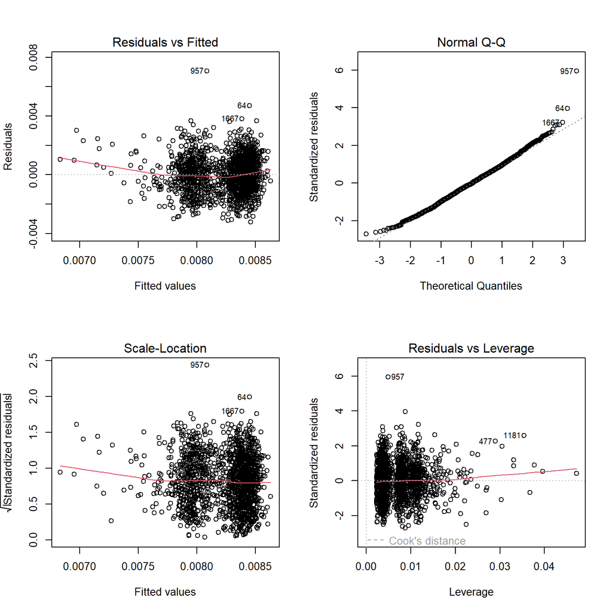

```r
par(mfrow = c(2,2)); plot(model2); par(mfrow = c(1,1))
```

**Normal Q-Q Plot** - The residuals on the QQ plot looks pretty normal. Also, there are a few outliers.

# 7 Comparing Models

```r
bind_rows(glance(model1), glance(model2)) |>
  mutate(mod_vars= c("model1", "model2")) |>
  select(mod_vars, r2 = r.squared, adj_r2 = adj.r.squared,
         sigma, AIC, BIC, df, df_res = df.residual) |>
  kable(digits = c(0, 4, 4, 5, 1, 0, 0, 0)) |> kable_minimal(font_size = 18)
```

| mod_vars | r2 | adj_r2 | sigma | AIC | BIC | df | df_res |
| --- | --- | --- | --- | --- | --- | --- | --- |
| model1 | 0.0151 | 0.0145 | 0.00120 | -18152.4 | -18136 | 1 | 1710 |
| model2 | 0.0420 | 0.0358 | 0.00119 | -18179.9 | -18109 | 11 | 1700 |

- Model 2 has highest r squared value and adjusted r square value.
- Model 2 has the smallest sigma value. (standard deviation of the residuals)
- Model 2 has the smallest AIC value, while model 1 has smallest BIC value.

```r
test_m1 <- augment(model1, newdata = study_b_test) |> mutate(model = "model1")
test_m2 <- augment(model2, newdata = study_b_test) |> mutate(model = "model2")


test_comp <- bind_rows(test_m1, test_m2) |>
  mutate(fit_sbp = 1/(.fitted), res_sbp = systolic_BP - fit_sbp) |>
  select(model, seqn, systolic_BP, fit_sbp, res_sbp)

test_comp |>
  group_by(model) |>
  summarise(MAPE = mean(abs(res_sbp)),
            RMSPE = sqrt(mean(res_sbp^2)),
            max_error = max(abs(res_sbp))) |>
  kbl(digits = c(3, 3, 3, 3)) |> kable_minimal(font_size = 18)
```

| model | MAPE | RMSPE | max_error |
| --- | --- | --- | --- |
| model1 | 13.944 | 18.144 | 85.668 |
| model2 | 13.652 | 17.785 | 86.266 |

- Model 2 has the smallest MAPE and RSMPE values, while Model 1 has smallest max error value.

# 8 Discussion

Judging the best model only based on r-squared value is not a good option, beacuse as we keep on adding the predictors the r-squared value increases. So, it is obvious the model with more predictors will have a higher r-squared value. Also adding an interaction term also increases the r-squared value. Taking into account AIC and BIC are equally important. However, as in our case, if one model has a small AIC value then the other model will have a small BIC value. But the best way to predict which model is the best among all is to look for smallest prediction errors.

## 8.1 Chosen Model

Overall model 2, the big model wins here (largest r-squared and smallest sigma, AIC, MAPE and RSMPE).

## 8.3 Next Steps

- Transforming predictors could be an approach too.
- Fitting a new model with an interaction terms would definitely improve the r squared value.
- There were a lot of missing data, so our findings cannot be generalized to the whole American population, obtaining better data could be another approach.